# Take-home Exercise 1

A new article created using the Distill format.

Huan Li https://linkedin.com/in/huan-li-ab7498124/  
2022-04-24

# 1. Overview

# 2. Data Preparation

## 2.1 Installing and loading the required libraries

The packages required are tidyverse (included relevant packages for data analyses such as [**ggplot2**](https://ggplot2.tidyverse.org/), [**readr**](https://readr.tidyverse.org/index.html) and [**dplyr**](https://dplyr.tidyverse.org/)), [**ggrepel**](https://cran.r-project.org/web/packages/ggrepel/vignettes/ggrepel.html),[**patchwork**](https://patchwork.data-imaginist.com/) and [**knitr**](https://yihui.org/knitr/).

The code chunk below is used to install and load the required packages onto RStudio.

```r
packages = c('tidyverse')

for (p in packages){
  if(!require(p, character.only = T)){
    install.package(p)
  }
  library(p, character.only = T)
}
library(patchwork)
```

## 2.2 Importing the Dataset

The code chunk below import *Participants.csv* from data folder into R by using [`read_csv()`](https://readr.tidyverse.org/reference/read_delim.html) of [**readr**](https://readr.tidyverse.org/index.html) package and save it as an tibble data frame called *participants*.

```r
participants <- read_csv("data/Participants.csv")
glimpse(participants)
```

```
Rows: 1,011
Columns: 7
$ participantId  <dbl> 0, 1, 2, 3, 4, 5, 6, 7, 8, 9, 10, 11, 12, 13,~
$ householdSize  <dbl> 3, 3, 3, 3, 3, 3, 3, 3, 3, 3, 3, 3, 3, 3, 3, ~
$ haveKids       <lgl> TRUE, TRUE, TRUE, TRUE, TRUE, TRUE, TRUE, TRU~
$ age            <dbl> 36, 25, 35, 21, 43, 32, 26, 27, 20, 35, 48, 2~
$ educationLevel <chr> "HighSchoolOrCollege", "HighSchoolOrCollege",~
$ interestGroup  <chr> "H", "B", "A", "I", "H", "D", "I", "A", "G", ~
$ joviality      <dbl> 0.001626703, 0.328086500, 0.393469590, 0.1380~
```

The table above shows that there are 7 columns 1011 rows in the dataset.

## 2.3 Explotatry Data Analysis of features

### 2.3.1 Dstribution of univariable

Before dig deep into the data, we use gg plot to visualize the distribution of all the columns.

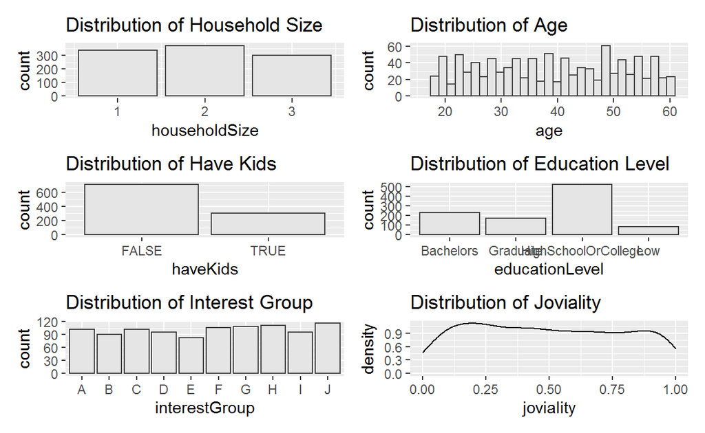

```r
p_householdsize <- ggplot(data = participants,
       aes(x = householdSize))+
  geom_bar(color="grey25",
           fill="grey90") +
  ggtitle("Distribution of Household Size")

p_havekids <- ggplot(data=participants,
             aes(x = haveKids)) +
  geom_bar(color="grey25",
           fill="grey90") +
  ggtitle("Distribution of Have Kids")

p_age <- ggplot(data=participants,
             aes(x = age)) +
  geom_histogram(boundary = 100,
                 color="grey25",
                 fill="grey90") +
  coord_cartesian(xlim=c(16, 61)) +
  ggtitle("Distribution of Age")

p_edu <- ggplot(data=participants,
             aes(x = educationLevel)) +
  geom_bar(boundary = 100,
                 color="grey25",
                 fill="grey90") +
  ggtitle("Distribution of Education Level")

p_interest <- ggplot(data=participants,
             aes(x = interestGroup)) +
  geom_bar(boundary = 100,
                 color="grey25",
                 fill="grey90") +
  ggtitle("Distribution of Interest Group")

p_joviality<- ggplot(data=participants,
             aes(x = joviality)) +
  geom_density() +
  ggtitle("Distribution of Joviality")

(p_householdsize/p_havekids/p_interest)|(p_age/p_edu/p_joviality)
```

Figure above shows that the data of householdsize, interest group and age are equally distributed. For other virables, we need to explore it further.

### 2.3.2 Linkage between variables

Let’s have a look at the relationship between variables.

```r
library(patchwork)

pl_hh <- ggplot(data = participants,
       aes(x = householdSize))+
  geom_bar()+
  geom_text(stat="count",
      aes(label=paste0(..count..,", ",
      round(..count../sum(..count..)*100,
        1),"%")),
      vjust=-1) +
  xlab("Household Size") +
  ylab("Count number of each household size") +
  theme(axis.title.y=element_text(angle = 0))

pl_jo <- ggplot(data=participants,
             aes(x = joviality)) +
  geom_histogram(bins = 10,
                 color="grey25",
                 fill="grey90") +
  coord_cartesian(xlim=c(0,1.2)) +
  ggtitle("Distribution of joviality")

pl_ag <- ggplot(data=participants,
             aes(x = age)) +
  geom_histogram(bins = 10,
                 boundary = 100,
                 color="grey25",
                 fill="grey90") +
  coord_cartesian(xlim=c(16, 70)) +
  ggtitle("Distribution of Age")
```

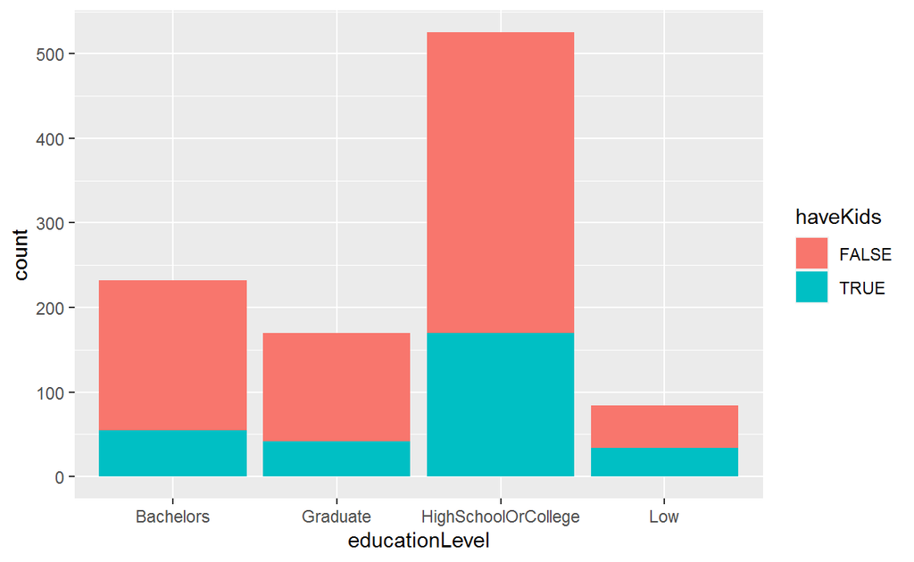

```r
ggplot(data = participants,
       aes(x = educationLevel, fill = haveKids))+
  geom_bar()
```

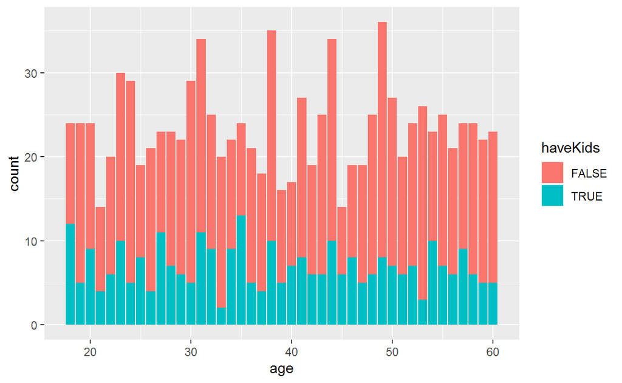

```r
ggplot(data = participants,
       aes(x = age, fill = haveKids))+
  geom_bar()
```